# Инфузории в фекалиях лошадей

В. М. Хайтов

2025-11-15

## Данные для анализа

После внимательного рассмотрения данных мне теперь кажется, что лучше работать с данными количественного учета. Однако тут всплыли несколько важных обстоятельств.

1. Оля почему-то поставила 0.01 во всех тех случаях, когда были нули в количественных оценках. НО! эти же нули (в тех же местах) были и в качественном анализе. То есть если вид был в качественном анализе, то он был и в количественном. Исключение составляет один единственный вид *P.minuta*. Ему я оставил 0.01. Во всех остальных случаях если вида не было в качественном анализе, то ставил 0. Проверьте, пожалуйста датасет.
2. В количественном анализе не разделяли виды *Bundleia*, а в качественном их различали. Поскольку количественные оценки имеют большую разрешающую способность, то предлагаю отказаться от деления на виды и в этом анализе их всех считать *Bundleia* sp.

Вот таблица первичных данных, которую я использую в дальнейшем анализе (Она также и в приложении в виде экселевского файла)

| Name | Sex | Origin | Type | C.edentatum | C.bipalmatum | T.parvum | T.unifasciculatum | T.caudatum | H.macrotricha | P.ampulla | Bundleia.sp | F.ovalis | P.colpoidea | D.quadrata. | B.curvigula | B.microcorys | C.minimum | B.jubata | B.angusta | S.confusum | P.minuta |
| --- | --- | --- | --- | --- | --- | --- | --- | --- | --- | --- | --- | --- | --- | --- | --- | --- | --- | --- | --- | --- | --- |
| Енисей | m | Or | Вольный | 0.25 | 0.33 | 0.67 | 6.00 | 9.33 | 30.01 | 54.67 | 64.67 | 11.00 | 0.25 | 0.00 | 6.67 | 0.00 | 0.00 | 0.00 | 0.00 | 0.00 | 0.00 |
| Олива | f | Fr | Вольный | 0.25 | 0.25 | 3.67 | 0.67 | 4.33 | 36.33 | 58.33 | 98.33 | 15.00 | 0.25 | 0.00 | 12.33 | 0.00 | 0.00 | 0.00 | 0.00 | 0.00 | 0.00 |
| Рица | f | Hu | Вольный | 2.33 | 0.67 | 0.25 | 0.67 | 0.67 | 0.33 | 3.67 | 7.33 | 3.33 | 0.00 | 3.67 | 1.00 | 1.67 | 0.00 | 0.00 | 0.00 | 0.00 | 0.00 |
| Саба | f | Hu | Вольный | 0.25 | 0.67 | 2.67 | 0.33 | 0.25 | 4.33 | 4.33 | 18.00 | 3.00 | 0.00 | 3.00 | 6.00 | 0.67 | 0.00 | 0.00 | 0.00 | 0.00 | 0.00 |
| Филипп | m | Or | Вольный | 0.25 | 0.67 | 0.33 | 0.67 | 0.25 | 8.67 | 7.33 | 7.33 | 3.00 | 0.25 | 5.67 | 4.67 | 4.00 | 1.33 | 0.00 | 0.00 | 0.00 | 0.00 |
| Аржаан | m | Or | Вольный | 1.00 | 2.00 | 2.67 | 2.00 | 2.67 | 26.33 | 17.00 | 33.67 | 2.67 | 0.00 | 1.67 | 8.00 | 0.00 | 0.00 | 0.00 | 0.00 | 0.00 | 0.00 |
| Арга | f | Hu | Вольный | 0.25 | 0.25 | 1.00 | 0.33 | 2.00 | 25.00 | 36.67 | 23.67 | 2.67 | 0.00 | 0.00 | 5.00 | 0.00 | 0.00 | 0.00 | 0.00 | 0.00 | 0.00 |
| Шикра | f | Hu | Вольный | 1.67 | 6.00 | 1.33 | 0.67 | 3.33 | 6.33 | 9.33 | 15.33 | 3.67 | 0.00 | 3.00 | 2.33 | 0.00 | 0.00 | 0.67 | 0.00 | 0.00 | 0.00 |
| Помпей | m | Hu | Загон | 4.00 | 2.67 | 0.25 | 0.00 | 0.25 | 0.00 | 2.67 | 5.33 | 0.25 | 0.00 | 1.33 | 8.00 | 2.67 | 0.00 | 0.00 | 0.00 | 0.00 | 0.00 |
| Паприка | f | Fr | Вольный | 0.33 | 0.33 | 0.25 | 1.33 | 0.67 | 0.67 | 2.00 | 4.00 | 0.25 | 0.00 | 0.67 | 1.33 | 0.00 | 0.00 | 0.00 | 0.00 | 0.00 | 0.00 |
| Эниф | m | Or | Загон | 0.67 | 0.25 | 0.00 | 0.25 | 0.25 | 0.00 | 0.00 | 2.00 | 0.00 | 0.00 | 0.00 | 0.33 | 0.67 | 0.33 | 0.00 | 0.00 | 0.00 | 0.00 |
| Буда | m | Or | Загон | 0.25 | 0.00 | 0.33 | 0.00 | 0.33 | 0.67 | 1.00 | 2.67 | 0.00 | 0.00 | 0.25 | 1.67 | 0.67 | 0.67 | 0.00 | 0.25 | 0.25 | 0.00 |
| Лаванда | f | Fr | Вольный | 0.67 | 0.33 | 0.25 | 0.25 | 0.25 | 0.33 | 1.00 | 0.25 | 0.00 | 0.25 | 0.25 | 0.33 | 0.00 | 0.25 | 0.00 | 0.00 | 0.00 | 0.01 |
| Сангрия | f | Fr | Вольный | 0.67 | 0.25 | 0.25 | 0.25 | 0.25 | 1.33 | 2.00 | 0.00 | 0.00 | 0.00 | 0.00 | 0.33 | 0.00 | 0.00 | 0.00 | 0.00 | 0.25 | 0.00 |

## Сравнение групп лошадей по составу сообщества инфузорий

Ординация сообществ на основе матрицы коэффициентов Брей-Куртиса

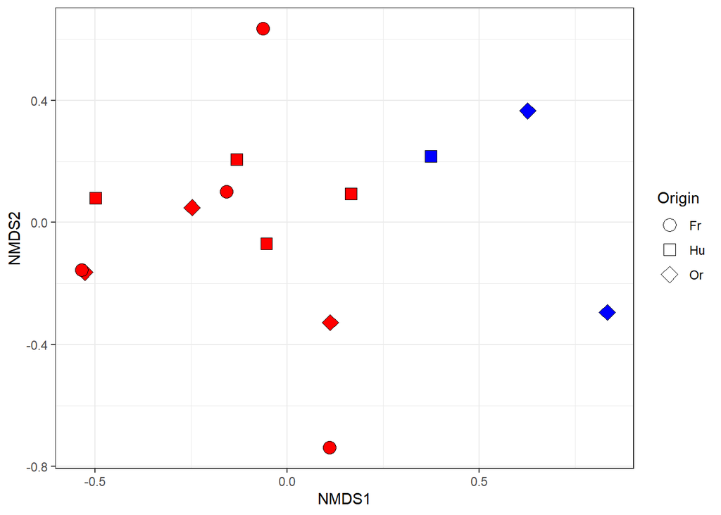

На ординации хорошо видно, что сообщество инфузорий из загонов отличается от сообществ свободных лошадей.

Для трактовки связей видов с типом местообитания приводим ординацию в тех же осях видов

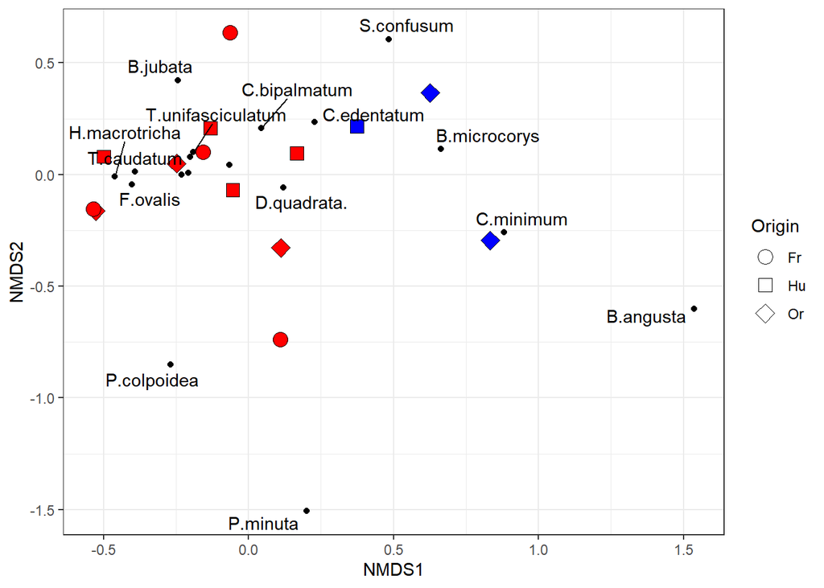

Следующие виды инфузорий более обильны сообществах у лошадей из загонов: S.confusum, C.edentatum, B.microcorys, C.minimum, B.angusta.

Для проверки статистической значимости влияния факторов на структуру сообщества применяем PERMANOVA (10000 пермутаций).

| term | df | SumOfSqs | R2 | statistic | p.value |
| --- | --- | --- | --- | --- | --- |
| Sex | 1 | 0.2347949 | 0.0734452 | 1.327572 | 0.2531747 |
| Type | 1 | 0.7322507 | 0.2290521 | 4.140276 | 0.0100990 |
| Origin | 2 | 0.8218040 | 0.2570649 | 2.323313 | 0.0407959 |
| Residual | 9 | 1.5917433 | 0.4979063 | NA | NA |
| Total | 13 | 3.1968733 | 1.0000000 | NA | NA |

Видно, что тип содержания лошадей оказывает значимое влияние. Для трактовки различий проведем анализ SIMPER.

[output not shown]

Кроме того, важно, что и фактор Origin играет роль.

```
##
## Contrast: Or_Fr
##
##                    average       sd    ratio      ava      avb cumsum      p
## Bundleia.sp        0.23023  0.11121  2.07020 22.06800 25.64500  0.325 0.1245
## P.ampulla          0.14715  0.08523  1.72650 16.00000 15.83200  0.533 0.3474
## H.macrotricha      0.11813  0.07735  1.52740 13.13600  9.66500  0.700 0.1817
## B.curvigula        0.04773  0.03141  1.51960  4.26800  3.58000  0.767 0.5508
## F.ovalis           0.03296  0.02453  1.34370  3.33400  3.81200  0.814 0.5881
## B.microcorys       0.02798  0.03208  0.87230  1.06800  0.00000  0.853 0.1028
## D.quadrata.        0.02441  0.03643  0.67010  1.51800  0.23000  0.888 0.6947
## T.unifasciculatum  0.01696  0.01878  0.90320  1.78400  0.62500  0.912 0.1127
## T.caudatum         0.01657  0.01537  1.07760  2.56600  1.37500  0.935 0.5563
## C.minimum          0.01275  0.01479  0.86220  0.46600  0.06200  0.953 0.0126 *
## T.parvum           0.01066  0.00911  1.16930  0.80000  1.10500  0.968 0.6026
## C.bipalmatum       0.00743  0.00757  0.98210  0.65000  0.29000  0.979 0.9136
## C.edentatum        0.00620  0.00944  0.65710  0.48400  0.48000  0.987 0.9433
## S.confusum         0.00323  0.00689  0.46870  0.05000  0.06200  0.992 0.1513
## P.colpoidea        0.00316  0.00706  0.44760  0.10000  0.12500  0.996 0.1534
## B.angusta          0.00244  0.00592  0.41200  0.05000  0.00000  1.000 0.0716 .
## P.minuta           0.00011  0.00029  0.38220  0.00000  0.00200  1.000 0.1489
## B.jubata           0.00000  0.00000      NaN  0.00000  0.00000  1.000 0.6427
## ---
## Signif. codes:  0 '***' 0.001 '**' 0.01 '*' 0.05 '.' 0.1 ' ' 1
##
## Contrast: Or_Hu
##
##                    average       sd    ratio      ava      avb cumsum     p
## Bundleia.sp        0.16503  0.08562  1.92740 22.06800 13.93200  0.267 0.940
## P.ampulla          0.13096  0.09252  1.41540 16.00000 11.33400  0.479 0.683
## H.macrotricha      0.10086  0.07288  1.38400 13.13600  7.19800  0.642 0.683
## B.curvigula        0.04394  0.05642  0.77880  4.26800  4.46600  0.714 0.718
## D.quadrata.        0.03138  0.03060  1.02540  1.51800  2.20000  0.764 0.339
## F.ovalis           0.03125  0.03014  1.03680  3.33400  2.58400  0.815 0.757
## C.bipalmatum       0.02334  0.03062  0.76210  0.65000  2.05200  0.853 0.228
## C.edentatum        0.02206  0.03003  0.73470  0.48400  1.70000  0.888 0.212
## T.caudatum         0.01784  0.01650  1.08120  2.56600  1.30000  0.917 0.448
## B.microcorys       0.01741  0.01799  0.96780  1.06800  1.00200  0.946 0.659
## T.parvum           0.01166  0.01372  0.85010  0.80000  1.10000  0.964 0.508
## T.unifasciculatum  0.01052  0.00871  1.20780  1.78400  0.40000  0.982 0.688
```

[output cut: 17 more lines]

```
## C.edentatum        0.02855  0.03539  0.80670  0.48000  1.70000  0.913 0.0507 .
## B.microcorys       0.02229  0.02984  0.74700  0.00000  1.00200  0.943 0.3322
## T.caudatum         0.01469  0.01603  0.91640  1.37500  1.30000  0.963 0.7584
## T.parvum           0.01326  0.01620  0.81870  1.10500  1.10000  0.981 0.2959
## T.unifasciculatum  0.00779  0.00850  0.91680  0.62500  0.40000  0.992 0.8949
## B.jubata           0.00177  0.00403  0.43980  0.00000  0.13400  0.994 0.2672
## P.colpoidea        0.00163  0.00265  0.61640  0.12500  0.00000  0.996 0.5441
## C.minimum          0.00141  0.00275  0.51310  0.06200  0.00000  0.998 0.9796
## S.confusum         0.00137  0.00266  0.51490  0.06200  0.00000  1.000 0.7113
## P.minuta           0.00006  0.00011  0.51310  0.00200  0.00000  1.000 0.5122
## B.angusta          0.00000  0.00000      NaN  0.00000  0.00000  1.000 0.6399
## ---
## Signif. codes:  0 '***' 0.001 '**' 0.01 '*' 0.05 '.' 0.1 ' ' 1
## Permutation: free
## Number of permutations: 10000
```

Значимое влияние этого фактора объясняется отличиями между Fr и Hu (не знаю, что это означает).

Отличия выявлены в обилии *F.ovalis* (больше в Fr, чем в Hu) и *C.edentatum* (больше в Hu, чем в Fr).

Также выявлены отличия между Or и Fr. C.minimum более обилен в Or, чем в Fr.

Дайте комментарии, пожалуйста! Эти различия как-то можно трактовать? Есл инет, то и думать наж этим пока не будем.